# APAN5205 Final Report PartA

2023-04-30

## Introduction

Disneyland is a world-renowned destination for visitors of all ages seeking an immersive entertainment experience. With multiple locations across the globe, Disneyland attracts people from all over the world, and provides visitors with unique cultural and recreational experiences. Understanding and catering to visitor’s demands and expectations is one of the most crucial aspects of running a successful Disneyland Branch.

This analysis aims to explore and identify the key factors that visitors care about during their visits to Disneyland at different locations across the world. Extensive research on visitors’ reviews and ratings will be conducted using a dataset that includes 42000 reviews and ratings of 3 most famous Disneyland branches - Paris, California, and Hong Kong. Another dataset used to support the analysis contains locations and types of Disneyland’s rides, which covers the majority of the rides facilitated at the three branches in this study. Other data such as general information about each branch will be collected and analyzed to support the study of visitor expectations.

Research questions exploring features that are potentially relevant to the sentiment of the review and/or the rating value would be raised and studied. These features include Park area, waiting times for rides, rides experience, amount of visitors, firework experiences, etc. By answering these questions, this analysis reveals insights about visitors’ perspectives and behaviors and will accordingly provide recommendations on how Disneyland at different locations may improve their offerings, enhance visitor experiences, and increase the overall satisfaction of visitors. With the recommendations, this research is expected to aid Disneyland to optimize its operations and make informed decisions for the future.

## Literature Review

By extracting data from an online review platform and pre-processing using text processing techniques, Jian Ming Luo and his team indicates that the popularity of topic words varies amongst theme parks and groups of visitors from different countries with topic modeling techniques (Luo & Yu, 2020). In their research, a comprehensive list of topics discussed by visitors in their reviews when visiting Disneyland theme parks is constructed to explore its relationship with review rating, which include “value for money”, “Dining options” and “Booking system” etc. It reveals that visitors tend to provide high ratings when they share happy experiences, while they tend to provide low ratings when they share other experiences such as value for money, food price, and cleanliness (Luo & Yu, 2020). Luo (2020) also mentions that queue time for riding is an important factor that negatively affects visitors’ experience, which results in low ratings. This review discusses the relationship between topic words existing in reviews and ratings by constructing topic modeling, which provides future research directions. It also illustrates the computation and frequency of topic probability by theme parks and visitors groups, which inspires our research to categorize reviews based on visitors’ nationality and locations of Disneyland they visited.

## Research Plan

### Research Questions

To examine the characteristics of online reviews that could potentially influence ratings of Disneyland Parks, and look for potential improvements for better visitor experience, we formulated the following potential research questions:

1. What is the relationship between reviewer location and the popularity of topics in their reviews?  
   Hypothesis 1:  
   Ho: Reviewers from different countries focusing on describing the same Disney experience topics.  
   Ha: Reviewers from different countries focusing on describing different Disney experience topics.  
   Hypothesis 2:  
   Ho: Reviewers from America and Canada mention car adventures in their reviews at the same or less frequency as reviewers from other countries.  
   Ha: Reviewers from America and Canada mention car adventure in their reviews more frequently than others.  
   Hypothesis 3:  
   Ho: Reviewers from Asian countries mention food in the reviews at the same or less frequency as reviewers from other continents. Ha: Reviewers from Asian countries mention food in their reviews more frequently than reviewers from other continents.
2. What is the relationship between Disneyland branches’ locations and the popularity of topics in reviews?  
   Hypothesis 1:  
   Ho: Reviews from different Disney branches focus on the same topics.  
   Ha: Reviews from different Disney branches focus on different topics.  
   Hypothesis 2:  
   Ho: Hong Kong Disneyland receives reviews related to shopping experiences in similar proportion as other branches.  
   Ha: Hong Kong Disneyland receives reviews related to shopping experiences in different proportion as other branches.  
   Hypothesis 3:  
   Ho: California Disneyland receives reviews related to rides experiences in similar proportion as other branches.  
   Ha: California Disneyland receives reviews related to rides experiences in different proportion as other branches.
3. We classified the topic words in the reviews into four categories: time, theme rides, dining, and customer services. Which specific topic words & topic words categories do reviewers share in their reviews when they tend to provide a high & low ratings?  
   Hypothesis 1:  
   Ho: Reviews discussing time words would not affect overall review ratings.  
   Ha: Reviews discussing time words would affect overall review ratings.  
   Hypothesis 2:  
   Ho: Reviews discussing food words would not affect overall review ratings.  
   Ha: Reviews discussing food words would affect overall review ratings.  
   Hypothesis 3:  
   Ho: Rides features would not affect overall review ratings.  
   Ha: Rides features would affect overall review ratings.  
   Hypothesis 4:  
   Ho: Reviews discussing staff would not affect overall review ratings.  
   Ha: Reviews discussing staff would affect overall review ratings.

## Data Cleaning

In this part, for the Disneyland dataset, we dropped missing values, separated Year and Month as independent columns, added a column to classify ratings into 3 categories: rating 1 and 2 as negative, 3 as neutral, and 4 and 5 as positive. We also added a continent column to our dataset to categorize reviewer’s resident locations. In the Rides dataset, we removed the missing value, converted “yes” and “no” in rides’ features columns into 1 and 0, and dropped redundant columns.

#### Disneyland Data

```r
library(stringr)
library(dplyr)
disney<-read.csv("DisneylandReviews.csv")
#summary(disney)
str(disney)
```

```
## 'data.frame':    42656 obs. of  6 variables:
##  $ Review_ID        : int  670772142 670682799 670623270 670607911 670607296 670591897 670585330 670574142 670571027 670570869 ...
##  $ Rating           : int  4 4 4 4 4 3 5 3 2 5 ...
##  $ Year_Month       : chr  "2019-4" "2019-5" "2019-4" "2019-4" ...
##  $ Reviewer_Location: chr  "Australia" "Philippines" "United Arab Emirates" "Australia" ...
##  $ Review_Text      : chr  "If you've ever been to Disneyland anywhere you'll find Disneyland Hong Kong very similar in the layout when you"| __truncated__ "Its been a while since d last time we visit HK Disneyland .. Yet, this time we only stay in Tomorrowland .. AKA"| __truncated__ "Thanks God …
##  $ Branch           : chr  "Disneyland_HongKong" "Disneyland_HongKong" "Disneyland_HongKong" "Disneyland_HongKong" ...
```

```r
glimpse(disney)
```

```
## Rows: 42,656
## Columns: 6
## $ Review_ID         <int> 670772142, 670682799, 670623270, 670607911, 67060729…
## $ Rating            <int> 4, 4, 4, 4, 4, 3, 5, 3, 2, 5, 5, 5, 4, 5, 5, 3, 4, 3…
## $ Year_Month        <chr> "2019-4", "2019-5", "2019-4", "2019-4", "2019-4", "2…
## $ Reviewer_Location <chr> "Australia", "Philippines", "United Arab Emirates", …
## $ Review_Text       <chr> "If you've ever been to Disneyland anywhere you'll f…
## $ Branch            <chr> "Disneyland_HongKong", "Disneyland_HongKong", "Disne…
```

```r
which(is.na(disney))
```

```
## integer(0)
```

```r
head(unique(disney$Year_Month))
```

```
## [1] "2019-4"  "2019-5"  "2019-3"  "2018-9"  "2019-1"  "2018-11"
```

```r
missing<- disney %>%
  filter(Year_Month == "missing")
#head(missing)
dim(missing)
```

```
## [1] 2613    6
```

```r
disneyland <- subset(disney, Year_Month!="missing")
dim(disneyland)
```

```
## [1] 40043     6
```

Now the dataset consists of 6 columns and 40043 rows.

We noticed that the `Year_Month` column is currently character class. We hope to convert it to a date class that could help future analysis.

```r
#install.packages("zoo")
library(zoo)
disneyland <- transform(disneyland, Year_Month = as.yearmon(Year_Month))
```

We want to separate out Year and Month as independent columns so that when exploring the data, the processing steps can be easier.

```r
#install.packages("lubridate")
library(lubridate)

disneyland <- disneyland %>%
  mutate(Year = year(Year_Month)) %>%
  mutate(Month = month(Year_Month))

#summary(disneyland)
#head(disneyland)
```

```r
# Ratings of Reviews
library(dplyr); library(magrittr)
unique(disneyland$Rating)
```

```
## [1] 4 3 5 2 1
```

```r
disneyland%>%
  summarize(average_rating = mean(Rating), median_rating = median(Rating))
```

```
##   average_rating median_rating
## 1       4.231102             5
```

```r
disneyland <- disneyland %>%
  mutate(Rating_type = case_when(Rating >= 4 ~ 'positive',
                                 Rating == 3 ~ 'neutral',
                                 Rating <= 2 ~ 'negative'))
#head(disneyland)
```

We found the ratings of all reviews ranged between 1 to 5 and the ratings are all integers. We calculated the average rating of all 40043 ratings is 4.231102. Based on the calculated average rating, we would add a column that classifies the `rating_type`. Any rating greater than or equal to 4 would be considered as “positive”; any rating that equals to 3 would be considered as “neutral”; any rating less than 3 would be considered “negative.”

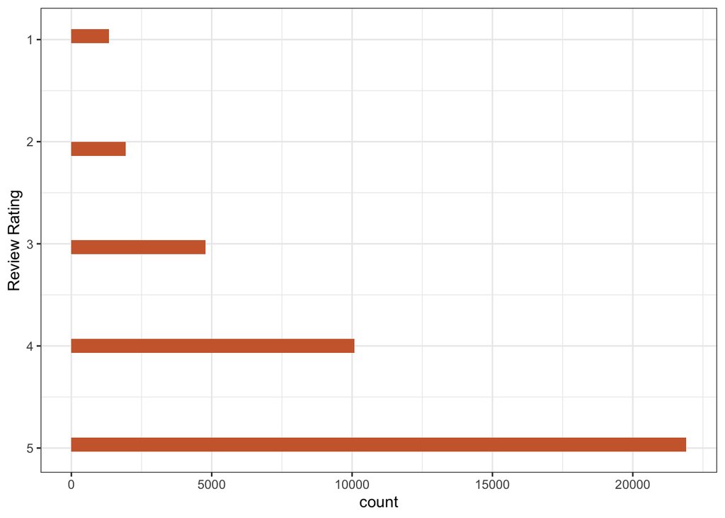

```r
# Distribution of Reviews
library(ggplot2)
#install.packages("ggthemes")
library(ggthemes)
ggplot(data=disneyland,aes(x=Rating))+
  geom_histogram(fill='sienna3')+
  theme_bw()+
  scale_x_reverse()+
  xlab('Review Rating')+
  coord_flip()
```

```r
# count the number of occurrence of each rating
table(disneyland$Rating)
```

```
##
##     1     2     3     4     5
##  1338  1929  4782 10086 21908
```

```r
# calculate each rating's proportion among all 40043 reviews
prop.table(table(disneyland$Rating))
```

```
##
##          1          2          3          4          5
## 0.03341408 0.04817321 0.11942162 0.25187923 0.54711185
```

```r
# count the number of occurrence of each rating_type
table(disneyland$Rating_type)
```

```
##
## negative  neutral positive
##     3267     4782    31994
```

Generally, over half of the total ratings are 5. And the “positive” rating occupies over 75% of the total reviews. Hence, for our future analysis, we would put more focus on evaluating the relationship between features mentioned in positive reviews and the rating.

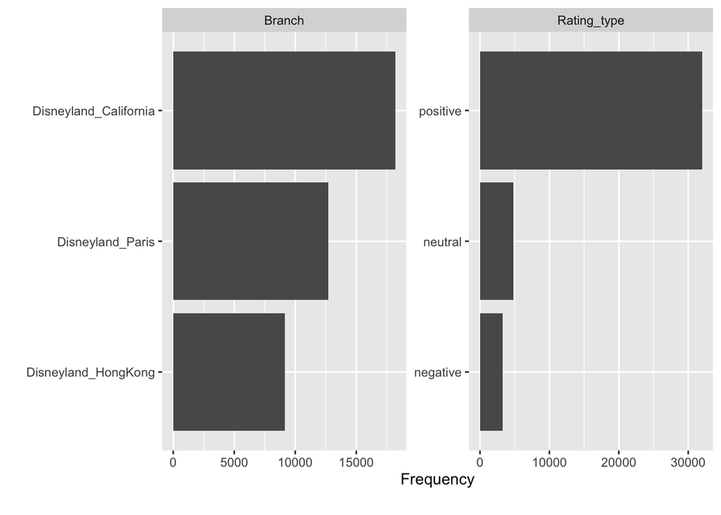

```r
#install.packages("DataExplorer")
library(DataExplorer)
#Bar charts and histograms for discrete and continuous variables
plot_bar(disneyland)
```

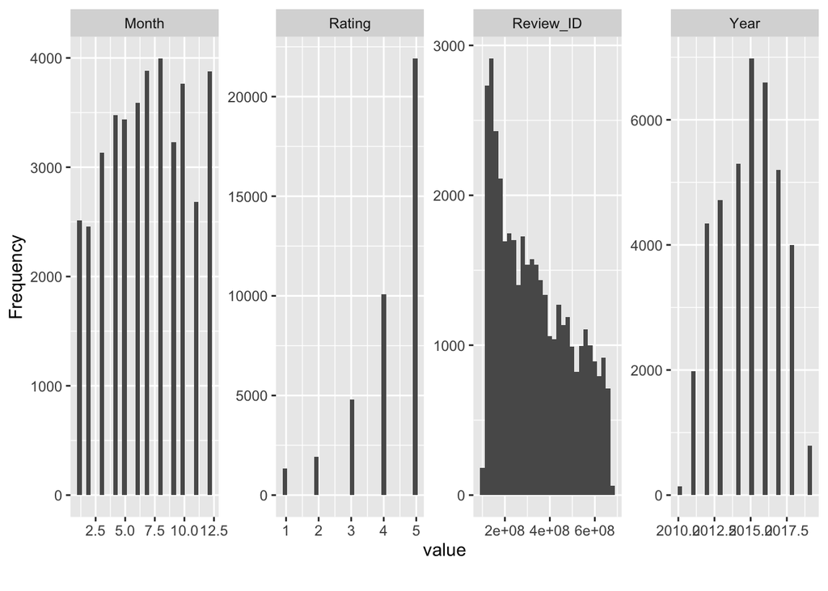

```r
plot_histogram(disneyland)
```

From the above bar plots, we again noticed that most of the reviews are positive. And we also noticed that most of the reviews are for Disneyland California branch. So, in our later analysis, we would also focus on if there is a relationship between Disney branch and rating. As well as if there are some features in California branch that are related to the rating type.

```r
# Reviewer_Location
length(unique(disneyland$Reviewer_Location))

# Clean locations with special characters
disneyland$Reviewer_Location[disneyland$Reviewer_Location == '\xc5land Islands'] <- 'Five Islands'
disneyland$Reviewer_Location[disneyland$Reviewer_Location == "C\xf4te d'Ivoire"] <- 'Ivory Coast'
disneyland$Reviewer_Location[disneyland$Reviewer_Location == "Cura\xe7ao"] <- 'Curacao'

table(disneyland$Reviewer_Location)
```

```r
#install.packages("countrycode")
library(countrycode)
disneyland$continent <- countrycode(sourcevar = disneyland[, "Reviewer_Location"],
                            origin = "country.name",
                            destination = "continent")
#head(disneyland)
```

We introduce the `library(countrycode)` to add a continent column to our dataset. In our future analysis, we hope to analyze reviewers’ preferences based on their continents and cultures.

```r
#write.csv(disneyland, "/Users/ruolinli/Desktop/APAN 5205/disneyland.csv", row.names=FALSE)
```

#### Rides Data

```r
# Load second dataset "rides"
rides <- read.csv("WDW_Ride_Data_DW.csv")
#head(rides)
str(rides)
```

```
## 'data.frame':    46 obs. of  28 variables:
##  $ Ride_name                : chr  "Alien Swirling Saucers" "Astro Orbiter" "Avatar Flight of Passage" "Big Thunder Mountain Railroad" ...
##  $ Park_location            : chr  "HS" "MK" "AK" "MK" ...
##  $ Park_area                : chr  "Toy Story Land" "Tomorrowland" "Pandora" "Frontierland" ...
##  $ Ride_type_all            : chr  "spinning" "spinning, slow" "thrill" "thirll, small drops" ...
##  $ Ride_type_thrill         : chr  "No" "No" "Yes" "Yes" ...
##  $ Ride_type_spinning       : chr  "Yes" "Yes" "No" "No" ...
##  $ Ride_type_slow           : chr  "No" "Yes" "No" "No" ...
##  $ Ride_type_small_drops    : chr  "No" "No" "No" "Yes" ...
##  $ Ride_type_big_drops      : chr  "No" "No" "No" "No" ...
##  $ Ride_type_dark           : chr  "No" "No" "No" "No" ...
##  $ Ride_type_scary          : chr  "No" "No" "No" "No" ...
##  $ Ride_type_water          : chr  "No" "No" "No" "No" ...
##  $ Fast_pass                : chr  "Yes" "No" "Yes" "Yes" ...
##  $ Classic                  : chr  "No" "Yes" "No" "Yes" ...
##  $ Age_interest_all         : chr  "all ages" "all ages" "kids, tweens, teens, adults" "kids, tweens, teens, adults" ...
##  $ Age_interest_preschoolers: chr  "Yes" "Yes" "No" "No" ...
##  $ Age_interest_kids        : chr  "Yes" "Yes" "Yes" "Yes" ...
##  $ Age_interest_tweens      : chr  "Yes" "Yes" "Yes" "Yes" ...
##  $ Age_interest_teens       : chr  "Yes" "Yes" "Yes" "Yes" ...
##  $ Age_interest_adults      : chr  "Yes" "Yes" "Yes" "Yes" ...
##  $ Height_req_inches        : int  32 0 44 40 0 40 0 44 0 0 ...
##  $ Ride_duration_min        : num  1.5 1.5 5 3.5 4 3.25 1.5 2.75 5 8 ...
##  $ Open_date                : chr  "6/30/18" "2/25/95" "5/27/17" "9/23/80" ...
##  $ Age_of_ride_days         : num  1712 10238 2111 15506 8918 ...
##  $ Age_of_ride_years        : num  4.69 28.03 5.78 42.45 24.42 ...
##  $ Age_of_ride_total        : chr  "4 years 8 months 7 days" "28 years 0 months 11 days" "5 years 9 months 11 days" "42 years 5 months 14 days" ...
##  $ TL_rank                  : int  31 43 9 8 32 24 29 1 27 47 ...
##  $ TA_Stars                 : num  NA 3.5 5 4.5 4.5 4 4.5 5 4 4 ...
```

```r
#glimpse(rides)
```

```r
sum(is.na(rides))
```

```
## [1] 4
```

```r
rides<-na.omit(rides)
rides<-rides[,-c(23:28)]
#head(rides)
```

```r
# Convert Yes/No to 1/0
rides <- rides %>%
  mutate(across(c(Ride_type_thrill, Ride_type_spinning, Ride_type_slow,
                  Ride_type_small_drops, Ride_type_big_drops, Ride_type_dark,
                  Ride_type_scary, Ride_type_water, Fast_pass, Classic,
                  Age_interest_preschoolers, Age_interest_kids,
                  Age_interest_tweens, Age_interest_teens,Age_interest_adults),
                  ~as.numeric(ifelse(.x == "Yes",1,0))))
```

We convert Yes/No values under each column to 1/0 for future analysis.

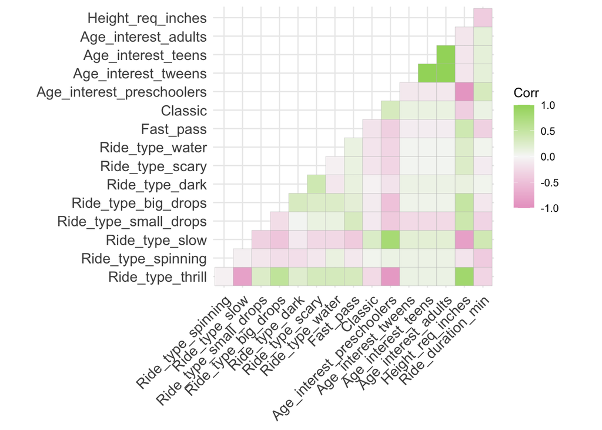

```r
#install.packages("ggcorrplot")
library(ggcorrplot)

rides_cor <- rides[,-c(1:4,15)]
ggcorrplot(cor(rides_cor),
           method = 'square',
           type = 'lower',
           show.diag = F,
           colors = c('#e9a3c9', '#f7f7f7', '#a1d76a'))
```

From the correlation plot, we can see that high correlations exist among `Age_interest_tweens`, `Age_interest_teens`, and `Age_interest_adults`, also between `Height_req_inches` and `Age_interest_preschoolers`, so we may less consider these variables when we analyze rides’ attributes.

```r
#example code
disney %>%
  filter(str_detect(Review_Text, "big thunder"))
```

In future analysis, we would join the two datasets (and possible other related datasets) together based on rides name mentioned in reviews. We expected to analyze if rides’ attributes such as darkness, intensity, speed, and targeting demographics would influence the overall rating customers have on Disney branches.

```r
#write.csv(disneyland, "/Users/ruolinli/Desktop/APAN 5205/rides.csv", row.names=FALSE)
```

## Review Column Explore

Firstly, we want to get a sense of the `Review_Text` column. Specifically, we want to know the number of characters, words, and sentences across all reviews; percentage of Screaming Review and the percentage of exclamation marks in the review.  
Since using uppercase and exclamation marks is usually a way to express feelings, we want to know if the use of uppercase and exclamation marks in review has any impact on review’s overall rating. Whether use of uppercase letters and exclamation marks would associate with more extreme ratings?

```r
#install.packages("readr")
library(readr)
library(tm)
library(dplyr)
library(magrittr)
library(stringr)

#summary of characters, words, and sentences across all reviews
summary(nchar(disneyland$Review_Text))
```

```
##    Min. 1st Qu.  Median    Mean 3rd Qu.    Max.
##    18.0   236.0   427.0   678.5   814.0 20756.0
```

```r
summary(str_count(string = disneyland$Review_Text, pattern = '\\S+'))
```

```
##    Min. 1st Qu.  Median    Mean 3rd Qu.    Max.
##     3.0    44.0    80.0   126.3   152.0  3963.0
```

```r
summary(str_count(string = disneyland$Review_Text, pattern =     "[A-Za-z,;'\"\\s]+[^.!?]*[.?!]"))
```

```
##    Min. 1st Qu.  Median    Mean 3rd Qu.    Max.
##   0.000   3.000   6.000   8.056  10.000 269.000
```

```r
#get the mean number of characters, words and sentences together
disneyland %>%
  select(Review_Text)%>%
  mutate(characters = nchar(Review_Text),
         words = str_count(Review_Text,pattern='\\S+'),
         sentences = str_count(Review_Text,pattern="[A-Za-z,;'\"\\s]+[^.!?]*[.?!]"))%>%
  summarize_at(c('characters','words','sentences'),.funs = mean,na.rm=T)
```

```
##   characters    words sentences
## 1   678.4696 126.3081  8.055915
```

```r
#Screaming Reviews:
percentUpper = 100*str_count(disneyland$Review_Text,pattern='[A-Z]')/nchar(disneyland$Review_Text)
summary(percentUpper)
```

```
##    Min. 1st Qu.  Median    Mean 3rd Qu.    Max.
##   0.000   1.758   2.415   2.674   3.271  50.000
```

```r
#Exclamation marks:
percentExclamation = 100*str_count(disneyland$Review_Text,pattern='!')/nchar(disneyland$Review_Text)
summary(percentExclamation)
```

```
##    Min. 1st Qu.  Median    Mean 3rd Qu.    Max.
##  0.0000  0.0000  0.0000  0.2438  0.2748 34.4262
```

```r
#impact of Upper Case and Exclamation marks on rating
r_upper = cor.test(percentUpper, disneyland$Rating)
r_exclamation = cor.test(percentExclamation, disneyland$Rating)
correlations = data.frame(r = c(r_upper$estimate, r_exclamation$estimate), p_value=c(r_upper$p.value, r_exclamation$p.value))
rownames(correlations) = c('Upper Case','Exclamation Marks')
correlations
```

```
##                            r      p_value
## Upper Case        0.07201835 3.365493e-47
## Exclamation Marks 0.10326489 2.342649e-95
```

Given two very small p-value, we could reject the null hypothesis (there is no effect between use of uppercase and exclamation marks and the overall review rating). Hence, we could conclude that the use of uppercase and exclamation marks has certain association with the Disneyland rating given by visitors.  
The use of uppercase might be a way to expression anger. And a set of consecutive exclamation marks may convey surprise or emphasis.

Now, we want to see what are the words existed frequently in `Review_Text`:

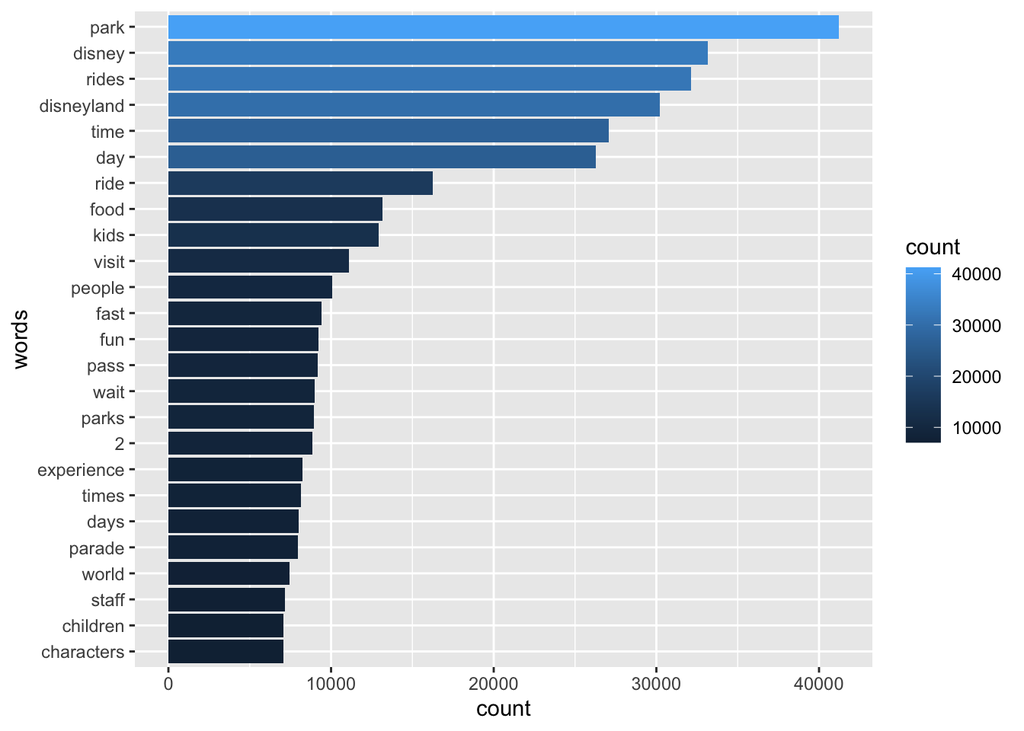

```r
#Finding common words existing in Review_Text (excluding stop words):
library(dplyr)
library(tidytext)
library(magrittr)

#observe and plot the top 25 common words:
disneyland %>%
  unnest_tokens(input = Review_Text, output = word)%>%
  select(word)%>%
  anti_join(stop_words)%>%
  group_by(word)%>%
  summarize(count = n())%>%
  ungroup()%>%
  arrange(desc(count))%>%
  top_n(25)%>%
  ggplot(aes(x=reorder(word,count), y=count, fill=count))+
    geom_col()+
    xlab('words')+
    coord_flip()
```

From the plot, we can see that words related to disneyland itself appear frequently: “park”, “disney”, “disneyland”, “visit”. “rides”, “time”, “day”, “food” and other words also existed frequently. We would explore the relationship between word occurrence and rating in our later research questions.

For all Disneyland reviews, we wonder if there is more positive feelings or more negative feelings. And what is the relationship between word sentiment and rating?

```r
head(disneyland)
```

```
##   Review_ID Rating Year_Month    Reviewer_Location
## 1 670772142      4   Apr 2019            Australia
## 2 670682799      4   May 2019          Philippines
## 3 670623270      4   Apr 2019 United Arab Emirates
## 4 670607911      4   Apr 2019            Australia
## 5 670607296      4   Apr 2019       United Kingdom
## 6 670591897      3   Apr 2019            Singapore
##                                                                                                                                                                                                                                                                                                          …
## 1                                                                                                                                                                                                                                                                                                        …
## 2 Its been a while since d last time we visit HK Disneyland .. Yet, this time we only stay in Tomorrowland .. AKA Marvel land!Now they have Iron Man Experience n d Newly open Ant Man n d Wasp!!Ironman .. Great feature n so Exciting, especially d whole scenery of HK (HK central area to Kowloon)!An…
## 3                                 Thanks God it wasn   t too hot or too humid when I was visiting the park   otherwise it would be a big issue (there is not a lot of shade).I have arrived around 10:30am and left at 6pm. Unfortunately I didn   t last until evening parade, but 8.5 hours was too muc…
## 4                                                                                                                                                                                                                                                                                                        …
## 5                                                                                                                                                                                                                                                                                                        …
## 6     Have been to Disney World, Disneyland Anaheim and Tokyo Disneyland but I feel that Disneyland Hong Kong is really too small to be called a Disneyland. It has way too few rides and attractions. Souvenirs, food and even entrance tickets are slightly more expensive than other Disneyland as wel…
##                Branch Year Month Rating_type continent
## 1 Disneyland_HongKong 2019     4    positive   Oceania
## 2 Disneyland_HongKong 2019     5    positive      Asia
## 3 Disneyland_HongKong 2019     4    positive      Asia
## 4 Disneyland_HongKong 2019     4    positive   Oceania
## 5 Disneyland_HongKong 2019     4    positive    Europe
## 6 Disneyland_HongKong 2019     4     neutral      Asia
```

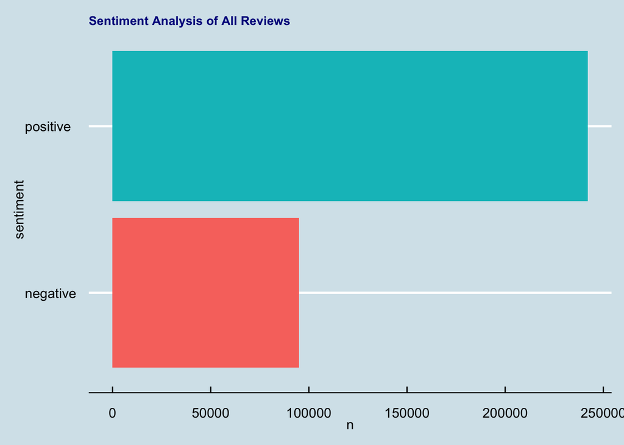

```r
#Use Binary Sentiment Lexicons to classify tokens into two categories: positive and negative
disneyland %>%
  group_by(Review_ID)%>%
  unnest_tokens(output = word, input = Review_Text)%>%
  inner_join(get_sentiments('bing'))%>%
  group_by(sentiment) %>%
  count() %>%
  ggplot(aes(x=sentiment,y=n,fill=sentiment))+
  geom_col()+
  theme_economist()+
  guides(fill=F)+
  coord_flip() +
  labs(title = "Sentiment Analysis of All Reviews") +
  theme(plot.title = element_text(size = 10, color = "darkblue"))
```

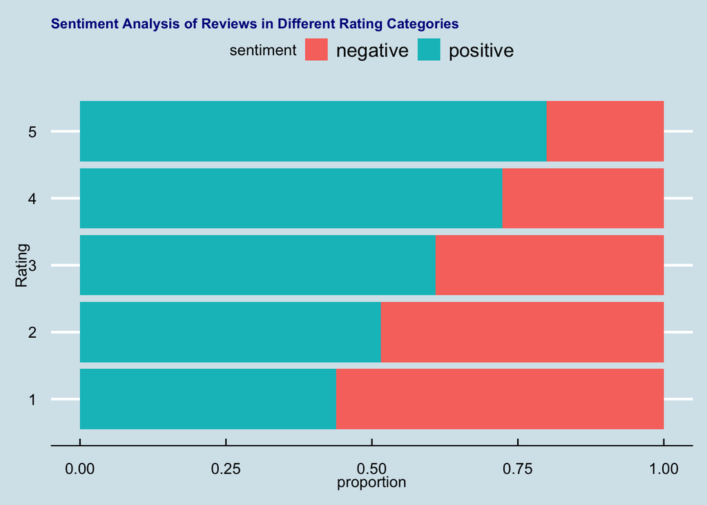

```r
# Sentiment Analysis of Reviews in Different Rating Categories
library(ggthemes)
disneyland %>%
  select(Review_ID, Review_Text, Rating)%>%
  group_by(Review_ID, Rating)%>%
  unnest_tokens(output = word,input = Review_Text)%>%
  ungroup()%>%
  inner_join(get_sentiments('bing'))%>%
  group_by(Rating, sentiment)%>%
  summarize(n = n())%>%
  mutate(proportion = n/sum(n)) %>%
  ggplot(aes(x=Rating,y=proportion,fill=sentiment))+
  geom_col()+
  theme_economist()+
  coord_flip() +
  labs(title = "Sentiment Analysis of Reviews in Different Rating Categories") +
  theme(plot.title = element_text(size = 10, color = "darkblue"))
```

We want to see emotions expressed in reviews as well:

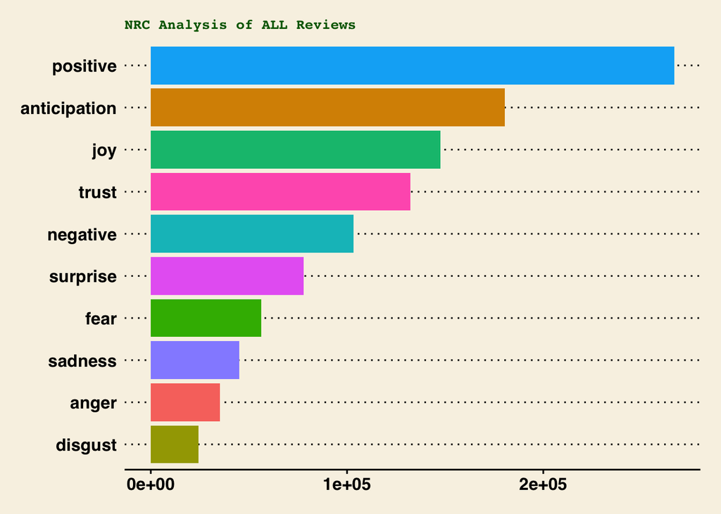

```r
#Examine emotions expressed in the reviews:
nrc = read.table(file = 'https://raw.githubusercontent.com/pseudorational/data/master/nrc_lexicon.txt',
                 header = F,
                 col.names = c('word','sentiment','num'),
                 sep = '\t',
                 stringsAsFactors = F)
nrc = nrc[nrc$num!=0,]
nrc$num = NULL

disneyland %>%
  group_by(Review_ID)%>%
  unnest_tokens(output = word, input = Review_Text)%>%
  inner_join(nrc)%>%
  group_by(sentiment)%>%
  count()%>%
  ggplot(aes(x=reorder(sentiment,X = n), y=n, fill=sentiment))+
  geom_col()+
  guides(fill=F)+
  coord_flip()+
  theme_wsj() +
  labs(title = "NRC Analysis of ALL Reviews") +
  theme(plot.title = element_text(size = 10, color = "darkgreen"))
```

```r
library(tidyr)
disneyland %>%
  group_by(Review_ID, Rating)%>%
  unnest_tokens(output = word, input = Review_Text)%>%
  inner_join(nrc)%>%
  group_by(Review_ID,Rating, sentiment)%>%
  count()%>%
  pivot_wider(names_from = sentiment,values_from=n)%>%
  select(Review_ID, Rating, positive, negative, trust, anticipation, joy, fear, anger, sadness, surprise, disgust)%>%
  mutate_at(.vars = 3:12, .funs = function(x) replace_na(x,0))%>%
  ungroup()
```

```
## # A tibble: 39,638 × 12
##    Review_ID Rating positive negative trust anticipa…¹   joy  fear anger sadness
##        <int>  <int>    <int>    <int> <int>      <int> <int> <int> <int>   <int>
##  1  91619113      5        6        0     4          3     4     0     0       0
##  2  91639166      4       13       11    10          6     9     2     2       3
##  3  91657810      4        3        2     2          2     2     0     1       1
##  4  91799423      5        6        2     2          5     4     0     0       1
##  5  91816335      2        1        2     0          2     0     0     0       0
##  6  91827418      5        4        4     1          5     3     3     0       1
##  7  91905355      5        3        0     2          3     2     0     0       0
##  8  91984642      2       14        9     6          7     6     5     2       4
##  9  91995748      1       16       17     9          4     7     5     8       5
## 10  92061774      4       31       13    14         26    12     3     4       5
## # … with 39,628 more rows, 2 more variables: surprise <int>, disgust <int>, and
## #   abbreviated variable name ¹anticipation
```

There are more than 200,000 positive words used in `Review_Text`, and there are many words express “anticipation”, “joy”, “trust” feelings in visitors’ Disney experience as well. There are about 100,000 negative words used in `Review_Text`, which is less than a half of positive words used. This aligns with our previous observation. We assume “fear”, “sadness”, “anger”, and “disgust” might exist in reviews with lower ratings.

We built a word cloud to give audience an intuition of the frequency of words used in reviews.

[figure not shown]

```r
#WordCloud:
#install.packages("wordcloud")
library(wordcloud)
wordcloudData =
  disneyland %>%
  group_by(Review_ID)%>%
  unnest_tokens(output=word,input=Review_Text)%>%
  ungroup()%>%
  select(Review_ID,word)%>%
  anti_join(stop_words)%>%
  group_by(word)%>%
  summarize(freq = n())%>%
  arrange(desc(freq))%>%
  ungroup()%>%
  data.frame()
library(wordcloud)
set.seed(617)
wordcloud(words = wordcloudData$word,wordcloudData$freq,scale=c(2,0.5),max.words = 100,colors=brewer.pal(9,"Set2"))
```

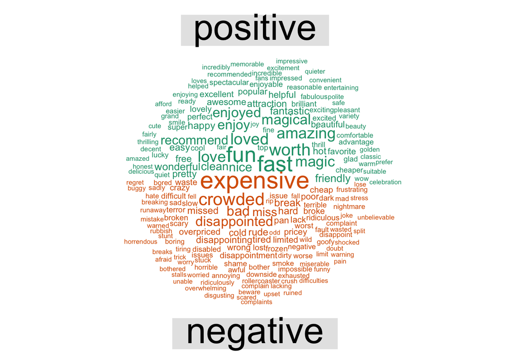

```r
library(tidyr)
wordcloudData =
  disneyland %>%
  group_by(Review_ID)%>%
  unnest_tokens(output=word, input = Review_Text)%>%
  ungroup()%>%
  select(Review_ID, word)%>%
  anti_join(stop_words)%>%
  inner_join(get_sentiments('bing'))%>%
  ungroup()%>%
  count(sentiment,word,sort=T)%>%
  pivot_wider(names_from = sentiment, values_from = n, values_fill = 0)%>%
  data.frame()
rownames(wordcloudData) = wordcloudData[,'word']
wordcloudData = wordcloudData[,c('positive','negative')]
set.seed(617)
comparison.cloud(term.matrix = wordcloudData,scale = c(2,0.5),max.words = 200, rot.per=0)
```

Using the above comparison cloud, we can visualize words and sentiment in `Review_Text`.

## Research Question No.1

### Hypothesis 1

In this section, we are going to examine the frequency of top words mentioned by different reviewers come from different continents.

Ho: Reviewers from different continents focusing on describing the same Disney experience top words.  
Ha: Reviewers from different continents focusing on describing different Disney experience top words.

There in total 5 continents where reviewers come from in the dataset.

```r
table(disneyland$continent)
```

```
##
##   Africa Americas     Asia   Europe  Oceania
##      429    16012     6711    11730     5159
```

Before analyzing focused on different reviewers’ continents, We invetigate the top 25 words mentioned by reviewers from all continents to figure out top words that appear commonly among all continents. “park”, “disney”,“disneyland”,“visit”,“day”,“2” are selected to be removed in different continents analysis becasue they have high frequency appeared among all continents and no specific representation.

#### Top 25 words mentioned by reviewers from all continents

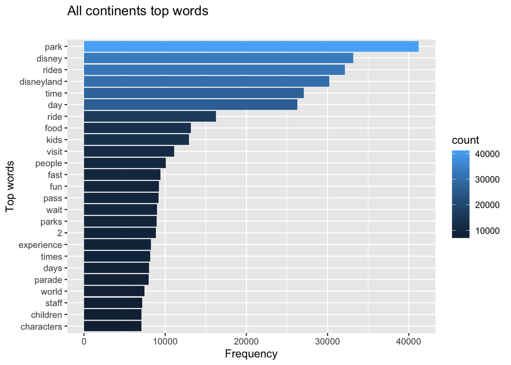

```r
disneyland%>%
  unnest_tokens(input = Review_Text, output = word)%>%
  select(word)%>%
  anti_join(stop_words)%>%
  group_by(word)%>%
  summarize(count = n())%>%
  ungroup()%>%
  arrange(desc(count))%>%
  top_n(25)%>%
  ggplot(aes(x=reorder(word,count), y=count, fill=count))+
    geom_col()+
    xlab('words')+
    coord_flip()+
    labs(x = "Top words",
       y = "Frequency",
       title = "All continents top words",
       subtitle = "")
```

To prepare data, we firstly split dataset based on reviewers’ continents into 5 subsets: reviewers from Africa, reviewers from Americas, reviewers from Asia, reviewers from Europe, reviewers from Oceania.

#### Split dataset based on reviewers’ continent

```r
africa_reviewer <- disneyland %>%
  filter(continent == 'Africa')
americas_reviewer <- disneyland %>%
  filter(continent == 'Americas')
asia_reviewer <- disneyland %>%
  filter(continent == 'Asia')
europe_reviewer <- disneyland %>%
  filter(continent == 'Europe')
oceania_reviewer <- disneyland %>%
  filter(continent == 'Oceania')
```

To analyze different continents’ top words frequency, we remove previous selected words without specific meaning and list top 10 words mentioned by reviewers from 5 continents.

#### Top 10 words mentioned by reviewers from Africa

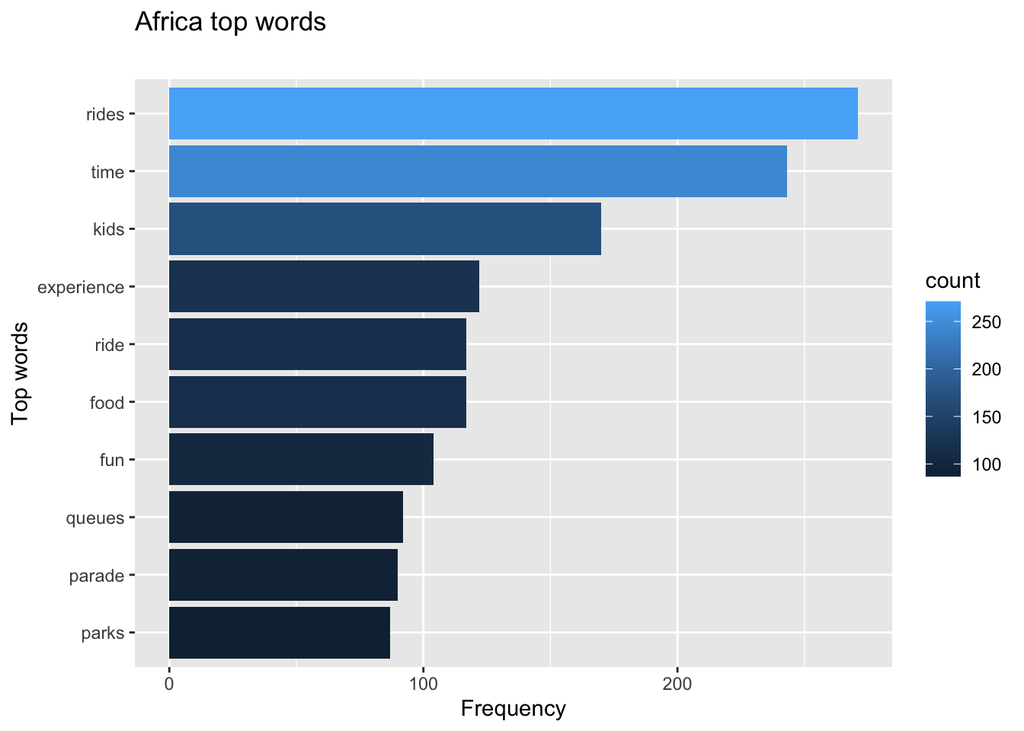

```r
africa_reviewer%>%
  unnest_tokens(input = Review_Text, output = word)%>%
  select(word)%>%
  anti_join(stop_words)%>%
  filter(!word %in% c("disneyland", "disney", "park", "visit", "day", "2")) %>%
  group_by(word)%>%
  summarize(count = n())%>%
  ungroup()%>%
  arrange(desc(count))%>%
  top_n(10)%>%
  ggplot(aes(x=reorder(word,count), y=count, fill=count))+
    geom_col()+
    xlab('words')+
    coord_flip()+
    labs(x = "Top words",
       y = "Frequency",
       title = "Africa top words",
       subtitle = "")
```

#### Top 10 words mentioned by reviewers from Americas

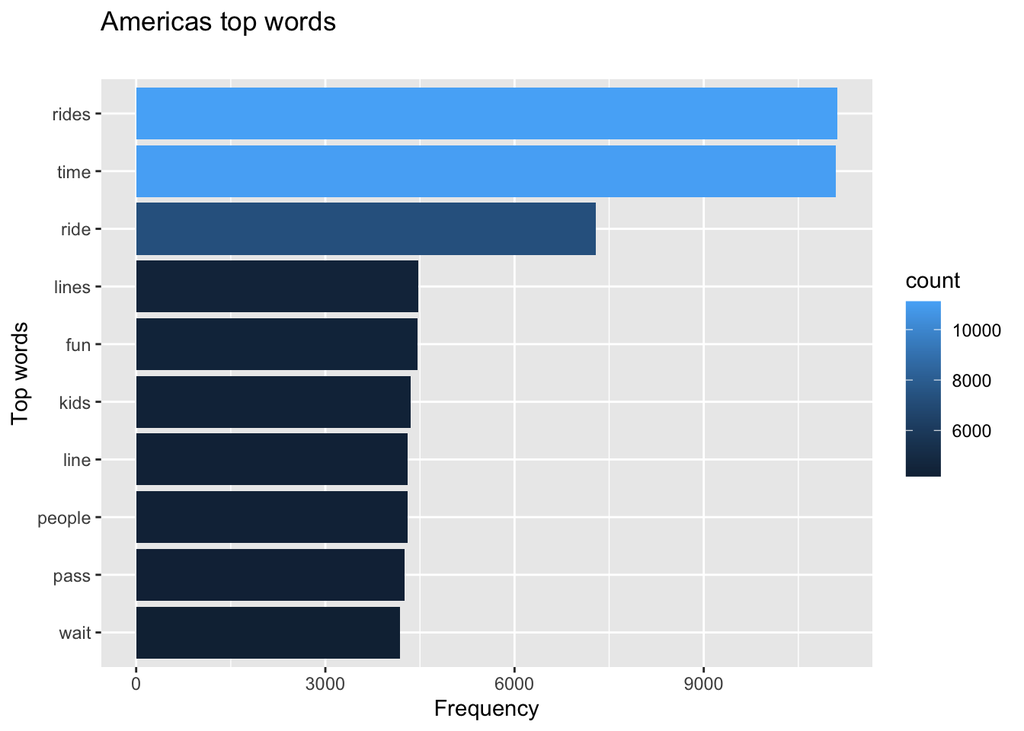

```r
americas_reviewer%>%
  unnest_tokens(input = Review_Text, output = word)%>%
  select(word)%>%
  anti_join(stop_words)%>%
  filter(!word %in% c("disneyland", "disney", "park", "visit", "day", "2")) %>%
  group_by(word)%>%
  summarize(count = n())%>%
  ungroup()%>%
  arrange(desc(count))%>%
  top_n(10)%>%
  ggplot(aes(x=reorder(word,count), y=count, fill=count))+
    geom_col()+
    xlab('words')+
    coord_flip()+
    labs(x = "Top words",
       y = "Frequency",
       title = "Americas top words",
       subtitle = "")
```

#### Top 10 words mentioned by reviewers from Asia

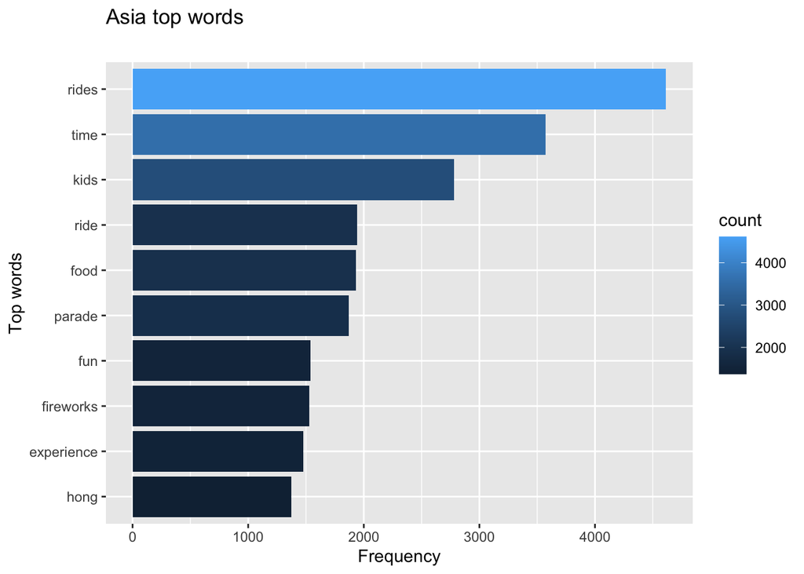

```r
asia_reviewer%>%
  unnest_tokens(input = Review_Text, output = word)%>%
  select(word)%>%
  anti_join(stop_words)%>%
  filter(!word %in% c("disneyland", "disney", "park", "visit", "day", "2")) %>%
  group_by(word)%>%
  summarize(count = n())%>%
  ungroup()%>%
  arrange(desc(count))%>%
  top_n(10)%>%
  ggplot(aes(x=reorder(word,count), y=count, fill=count))+
    geom_col()+
    xlab('words')+
    coord_flip()+
    labs(x = "Top words",
       y = "Frequency",
       title = "Asia top words",
       subtitle = "")
```

#### Top 10 words mentioned by reviewers from Europe

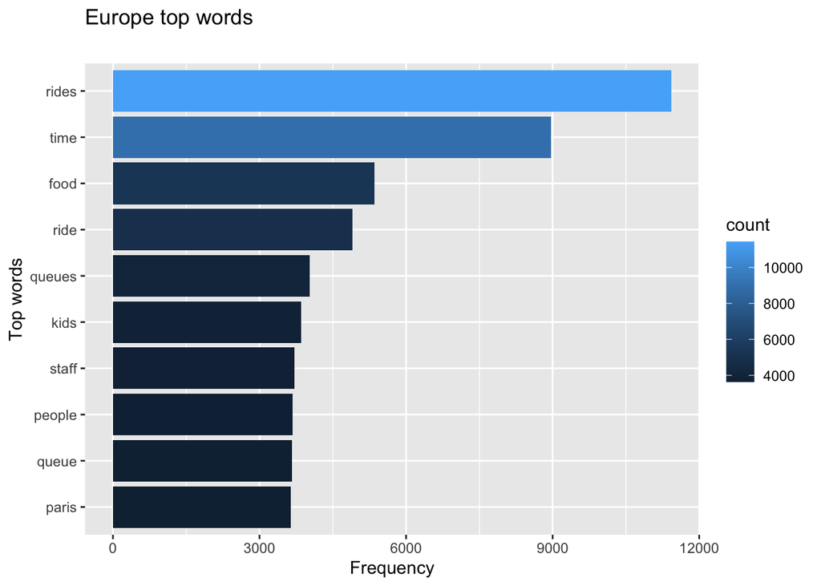

```r
europe_reviewer%>%
  unnest_tokens(input = Review_Text, output = word)%>%
  select(word)%>%
  anti_join(stop_words)%>%
  filter(!word %in% c("disneyland", "disney", "park", "visit", "day", "2")) %>%
  group_by(word)%>%
  summarize(count = n())%>%
  ungroup()%>%
  arrange(desc(count))%>%
  top_n(10)%>%
  ggplot(aes(x=reorder(word,count), y=count, fill=count))+
    geom_col()+
    xlab('words')+
    coord_flip()+
    labs(x = "Top words",
       y = "Frequency",
       title = "Europe top words",
       subtitle = "")
```

#### Top 10 words mentioned by reviewers from Oceania

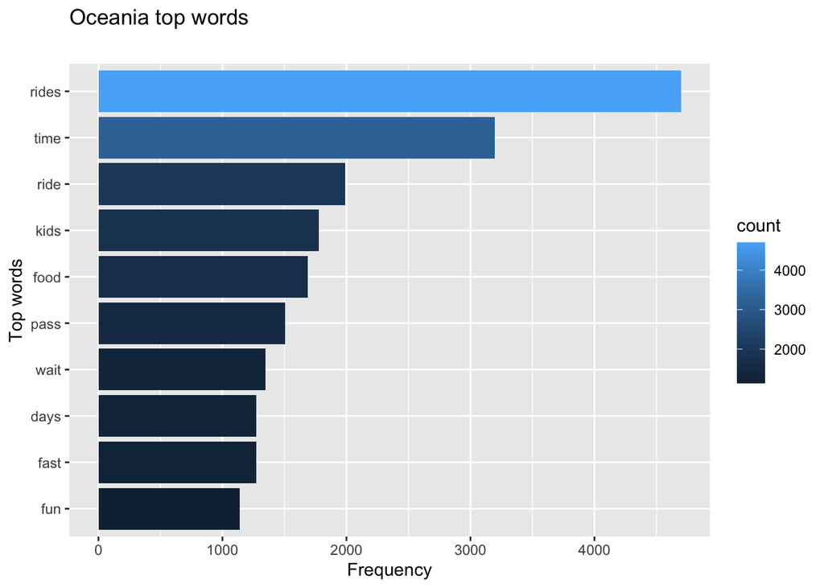

```r
oceania_reviewer%>%
  unnest_tokens(input = Review_Text, output = word)%>%
  select(word)%>%
  anti_join(stop_words)%>%
  filter(!word %in% c("disneyland", "disney", "park", "visit", "day", "2")) %>%
  group_by(word)%>%
  summarize(count = n())%>%
  ungroup()%>%
  arrange(desc(count))%>%
  top_n(10)%>%
  ggplot(aes(x=reorder(word,count), y=count, fill=count))+
    geom_col()+
    xlab('words')+
    coord_flip()+
    labs(x = "Top words",
       y = "Frequency",
       title = "Oceania top words",
       subtitle = "")
```

From the above analysis, we can figure out some similarities:

1. “Rides” and “ride” are among the most frequently mentioned words across all five continents, indicating that amusement parks and similar attractions are popular around the world.
2. “Time” is frequently mentioned across all continents, suggesting that efficiency and promptness are valued by reviewers globally.
3. “Kids” is another commonly mentioned word across all continents, indicating that many reviewers visit these attractions with children.

Also there are differences:

1. “Food” is a frequently mentioned word in Africa, Asia, Europe, and Oceania, suggesting that food options and quality are an important aspect of the overall experience for reviewers from these continents.
2. Topic words about queuing and waiting (“queues”,“queue”, “lines”, “wait”) are mentioned in Africa, Americas, Europe, and Oceania, and none of these words are mentioned in Asia.This could indicate that there are differences in the theme or experience of queuing or waiting in amusement parks or related attractions between these regions.
3. Topic words about Disneyland’s special events (“Parade”, “Fireworks”) in Africa and Asia.It may indicate that Disneyland’s parades and fireworks shows are a unique and important aspect of the park’s experience for visitors from these continents. Meanwhile, the absence of these words in the top word lists for Europe and the Americas may suggest that these special events are relatively less important or less prominent in those regions, or that visitors from those regions have different expectations or preferences when it comes to amusement park experiences.

### Hypothesis 2

In this section, we are going to examine the proportion of reviews that mention car adventure related words.

Ho: Reviewers from America and Canada mention car adventures in their reviews at the same or less frequency as reviewers from other countries. Ha: Reviewers from America and Canada mention car adventure in their reviews more frequently than others.

#### 1. Prepare Data

##### Split dataset based on reviewer country/continent

To prepare data, we firstly split dataset based on reviewers’ countries into reviewers in America and Canada and reviewers in other countries (expect America and Canada).

```r
ac_reviewer <- disneyland %>%
  filter(Reviewer_Location %in% c('United States', 'Canada'))
ac_other_reviewer <- disneyland %>%
  filter(!Reviewer_Location %in% c('United States', 'Canada'))
```

##### Create corpus

```r
corpus_ac = Corpus(VectorSource(ac_reviewer$Review_Text))
corpus_ac_other = Corpus(VectorSource(ac_other_reviewer$Review_Text))
```

##### Convert text to lower case

```r
corpus_ac = tm_map(corpus_ac,FUN = content_transformer(tolower))
corpus_ac_other = tm_map(corpus_ac_other,FUN = content_transformer(tolower))
```

#### 2. Data Explore

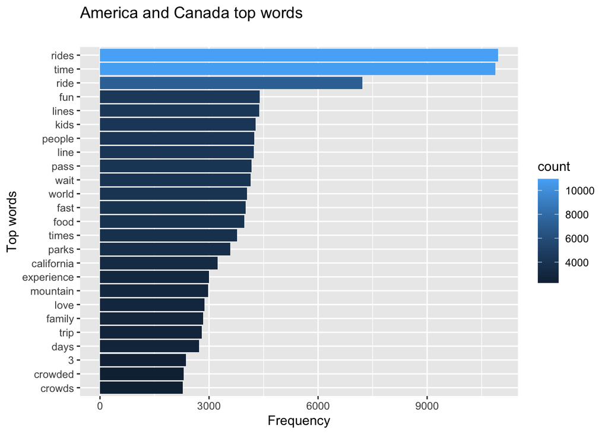

```r
ac_reviewer%>%
  unnest_tokens(input = Review_Text, output = word)%>%
  select(word)%>%
  anti_join(stop_words)%>%
  filter(!word %in% c("disneyland", "disney", "park", "visit", "day", "2")) %>%
  group_by(word)%>%
  summarize(count = n())%>%
  ungroup()%>%
  arrange(desc(count))%>%
  top_n(25)%>%
  ggplot(aes(x=reorder(word,count), y=count, fill=count))+
    geom_col()+
    xlab('words')+
    coord_flip()+
    labs(x = "Top words",
       y = "Frequency",
       title = "America and Canada top words",
       subtitle = "")
```

##### Top 25 words mentioned by reviewers from other countries except America and Canada

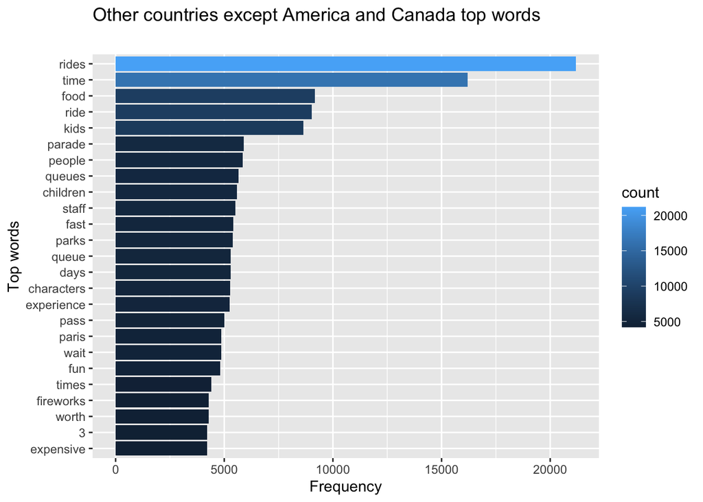

```r
ac_other_reviewer%>%
  unnest_tokens(input = Review_Text, output = word)%>%
  select(word)%>%
  anti_join(stop_words)%>%
  filter(!word %in% c("disneyland", "disney", "park", "visit", "day", "2")) %>%
  group_by(word)%>%
  summarize(count = n())%>%
  ungroup()%>%
  arrange(desc(count))%>%
  top_n(25)%>%
  ggplot(aes(x=reorder(word,count), y=count, fill=count))+
    geom_col()+
    xlab('words')+
    coord_flip()+
    labs(x = "Top words",
       y = "Frequency",
       title = "Other countries except America and Canada top words",
       subtitle = "")
```

#### 3. America & Canada car related words frequency and sentiment analysis

##### Frequency analysis

To analyze car related words frequency in American and Canadian reviewers, we begin with picking key words for retained car related words. Directly car related words include: “car”,“vehicle”. We also include names of rides with car concepts in Disneyland: Radiator Springs Racers, Autopia, and Luigi Rollickin Roadsters.

##### Retain car related words only

```r
car_words <- c(
  'car', 'vehicle',
  'radiator','springs','racers','autopia',
  'luigi','rollickin','roadsters')
```

```r
corpus <- corpus_ac
corpus = tm_map(corpus,FUN = removePunctuation)
corpus = tm_map(corpus,FUN = removeWords,c(stopwords('english')))
corpus = tm_map(corpus,FUN = stripWhitespace)
corpus = tm_map(corpus,FUN = stemDocument)
dtm_ac <- DocumentTermMatrix(corpus)
words_remove <- setdiff(colnames(dtm_ac), car_words)
length(words_remove)
```

```
## [1] 23933
```

```r
corpus = tm_map(corpus, FUN = removeWords, words_remove[1:4000])
corpus = tm_map(corpus, FUN = removeWords, words_remove[4001:7000])
corpus = tm_map(corpus, FUN = removeWords, words_remove[7001:10000])
corpus = tm_map(corpus, FUN = removeWords, words_remove[10001:13000])
corpus = tm_map(corpus, FUN = removeWords, words_remove[13001:16000])
corpus = tm_map(corpus, FUN = removeWords, words_remove[16001:19000])
corpus = tm_map(corpus, FUN = removeWords, words_remove[19001:22000])
corpus = tm_map(corpus, FUN = removeWords, words_remove[22001:23933])
corpus = tm_map(corpus, FUN = removeNumbers)
# transform to document term matrix
dtm_ac_then <- DocumentTermMatrix(corpus)
colnames(dtm_ac_then)
```

```
## [1] "car"     "autopia" "luigi"
```

```r
# make data frame
dtm_ac_then = as.data.frame(as.matrix(dtm_ac_then))
sort(colSums(dtm_ac_then),decreasing = T)
```

```
##     car autopia   luigi
##    1010     130      10
```

```r
# add a column counting the number of car related words in a review
dtm_ac_then['car_word_count'] = rowSums(dtm_ac_then)
# add a column specifying if a review contains car related words
dtm_ac_then['if_car_word'] = ifelse(dtm_ac_then$car_word_count >= 1, 1, 0)
# percentage of car related reviews
sum(dtm_ac_then$if_car_word) / nrow(dtm_ac_then) #0.0569766
```

```
## [1] 0.0569766
```

#### Sentiment Analysis

```r
ac_new = cbind(ac_reviewer, dtm_ac_then)
ac_car_sentiment = ac_new %>% filter(if_car_word ==1)
```

##### Clean the text

```r
# Convert to lower case
ac_car_sentiment$Review_Clean <- tolower(ac_car_sentiment$Review_Text)

# Remove Stopwords
ac_car_sentiment$Review_Clean <- lapply(strsplit(ac_car_sentiment$Review_Clean, "\\s+"), function(x) paste(x[!x %in% stopwords('english')], collapse = " "))
ac_car_sentiment$Review_Clean <- unlist(ac_car_sentiment$Review_Clean)
```

```r
#install.packages('textdata')
afinn = get_sentiments('afinn')

ac_car_sentiment %>%
  select(Review_ID,Review_Clean)%>%
  group_by(Review_ID)%>%
  unnest_tokens(output=word,input=Review_Clean)%>%
  inner_join(afinn)%>%
  summarize(reviewSentiment = mean(value))%>%
  ungroup()%>%
  summarize(min=min(reviewSentiment),
            max=max(reviewSentiment),
            median=median(reviewSentiment),
            mean=mean(reviewSentiment))
```

```
## # A tibble: 1 × 4
##     min   max median  mean
##   <dbl> <dbl>  <dbl> <dbl>
## 1    -3     4   1.47  1.41
```

```r
#1.411412
```

#### 4. Other countires except America & Canada car related words frequency analysis

```r
corpus <- corpus_ac_other
corpus = tm_map(corpus,FUN = removePunctuation)
corpus = tm_map(corpus,FUN = removeWords,c(stopwords('english')))
corpus = tm_map(corpus,FUN = stripWhitespace)
corpus = tm_map(corpus,FUN = stemDocument)
dtm_ac_other <- DocumentTermMatrix(corpus)
words_remove <- setdiff(colnames(dtm_ac_other), car_words)
length(words_remove)
```

```
## [1] 43742
```

```r
corpus = tm_map(corpus, FUN = removeWords, words_remove[1:4000])
corpus = tm_map(corpus, FUN = removeWords, words_remove[4001:7000])
corpus = tm_map(corpus, FUN = removeWords, words_remove[7001:10000])
corpus = tm_map(corpus, FUN = removeWords, words_remove[10001:13000])
corpus = tm_map(corpus, FUN = removeWords, words_remove[13001:16000])
corpus = tm_map(corpus, FUN = removeWords, words_remove[16001:19000])
corpus = tm_map(corpus, FUN = removeWords, words_remove[19001:22000])
corpus = tm_map(corpus, FUN = removeWords, words_remove[22001:25000])
corpus = tm_map(corpus, FUN = removeWords, words_remove[25001:28000])
corpus = tm_map(corpus, FUN = removeWords, words_remove[28001:31000])
corpus = tm_map(corpus, FUN = removeWords, words_remove[31001:34000])
corpus = tm_map(corpus, FUN = removeWords, words_remove[34001:37000])
corpus = tm_map(corpus, FUN = removeWords, words_remove[37001:40000])
corpus = tm_map(corpus, FUN = removeWords, words_remove[40001:43000])
corpus = tm_map(corpus, FUN = removeWords, words_remove[43001:43742])
corpus = tm_map(corpus, FUN = removeNumbers)
# transform to document term matrix
dtm_ac_other_then <- DocumentTermMatrix(corpus)
colnames(dtm_ac_other_then)
```

```
## [1] "car"     "autopia" "luigi"
```

```r
# make data frame
dtm_ac_other_then = as.data.frame(as.matrix(dtm_ac_other_then))
sort(colSums(dtm_ac_other_then),decreasing = T)
```

```
##     car autopia   luigi
##    1231     229       1
```

```r
# add a column counting the number of car related words in a review
dtm_ac_other_then['car_word_count'] = rowSums(dtm_ac_other_then)
# add a column specifying if a review contains car related words
dtm_ac_other_then['if_car_word'] = ifelse(dtm_ac_other_then$car_word_count >= 1, 1, 0)
# percentage of car related reviews
sum(dtm_ac_other_then$if_car_word) / nrow(dtm_ac_other_then) #0.04708052
```

```
## [1] 0.04708052
```

The proportion of car adventure related words mentioned in American and Canadian reviewers’ reviews is 0.0569766, while the proportion of car adventure related words mentioned in other countries (except America and Canadia) reviewers’ reviews is 0.04708052. It is indicated that American and Canadian reviewers’ frequency of mentioning car adventure related words is 0.989608% higher than other countries.

The effect size is greater than the set threshold of 0.5%, and the null hypothesis is rejected. It means that reviewers from America and Canada mention car adventure in their reviews more frequently than others.It indicates that when American and Canadian reviewers do mention car adventure in their reviews, they tend to have a positive sentiment towards it, with an average sentiment score of 1.411412.

### Hypothesis 3

In this section, we are going to examine the proportion of reviews that mention food-related words.

Ho: Reviewers from Asian countries mention food in the reviews at the same or less frequency as reviewers from other continents. Ha: Reviewers from Asian countries mention food in their reviews more frequently than reviewers from other continents.

#### 1. Prepare Data

##### Split dataset based on reviewer continent

To prepare data, we firstly split dataset based on reviewers’ continents into reviewers in Asian and reviewers in other continents expect Asia.

```r
asian_reviewer <- disneyland %>%
  filter(continent == 'Asia')
asian_other_reviewer <- disneyland %>%
  filter(continent != 'Asia')
```

##### Create corpus

```r
corpus_asian = Corpus(VectorSource(asian_reviewer$Review_Text))
corpus_asia_other = Corpus(VectorSource(asian_other_reviewer$Review_Text))
```

##### Convert text to lower case

```r
corpus_asian = tm_map(corpus_asian,FUN = content_transformer(tolower))
corpus_asia_other = tm_map(corpus_asia_other,FUN = content_transformer(tolower))
```

#### 2. Data Explore

##### Top 15 words mentioned by reviewers from Asia

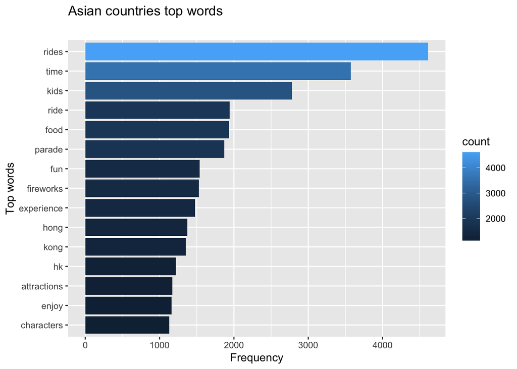

```r
asian_reviewer%>%
  unnest_tokens(input = Review_Text, output = word)%>%
  select(word)%>%
  anti_join(stop_words)%>%
  filter(!word %in% c("disneyland", "disney", "park", "visit", "day", "2")) %>%
  group_by(word)%>%
  summarize(count = n())%>%
  ungroup()%>%
  arrange(desc(count))%>%
  top_n(15)%>%
  ggplot(aes(x=reorder(word,count), y=count, fill=count))+
    geom_col()+
    xlab('words')+
    coord_flip()+
    labs(x = "Top words",
       y = "Frequency",
       title = "Asian countries top words",
       subtitle = "")
```

##### Top 15 words mentioned by reviewers from continents other than Asia

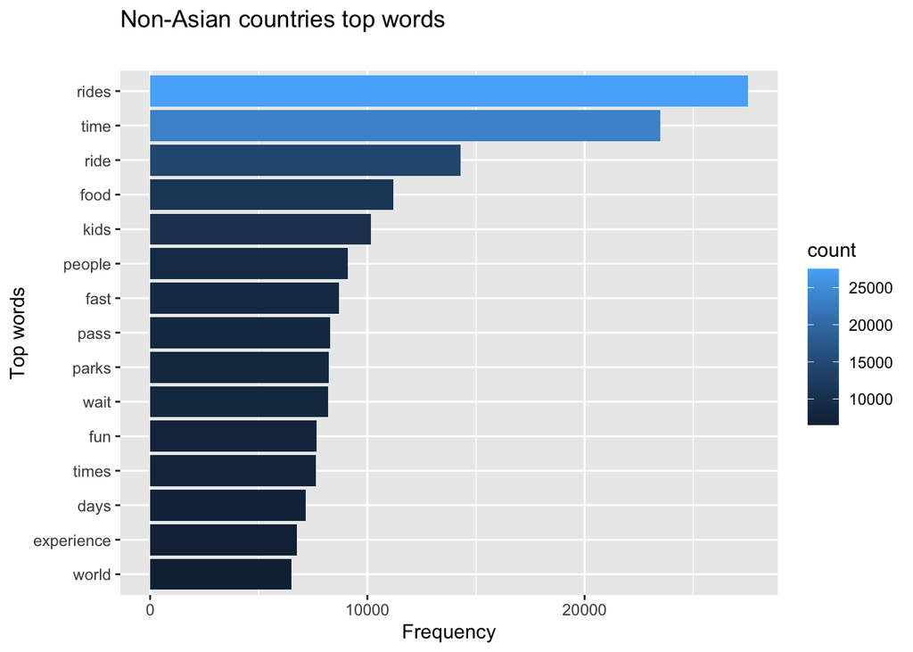

```r
asian_other_reviewer%>%
  unnest_tokens(input = Review_Text, output = word)%>%
  select(word)%>%
  anti_join(stop_words)%>%
  filter(!word %in% c("disneyland", "disney", "park", "visit", "day", "2")) %>%
  group_by(word)%>%
  summarize(count = n())%>%
  ungroup()%>%
  arrange(desc(count))%>%
  top_n(15)%>%
  ggplot(aes(x=reorder(word,count), y=count, fill=count))+
    geom_col()+
    xlab('words')+
    coord_flip()+
    labs(x = "Top words",
       y = "Frequency",
       title = "Non-Asian countries top words",
       subtitle = "")
```

After filtering out the common mentioned words, we can see from the charts that both Asian and non-Asian reviewers include a lot of ‘food’ words in their reviews. Asian reviewers also mention a lot of ‘Hong Kong’ related words which is located in Asia, this implies that visitors may tend to visit the Disney theme parks near where they are located.

#### 3. Asia food related words frequency analysis

#### Frequency analysis

To analyze food related words frequency in Asian reviewers, we begin with picking a list of food related words that are related to Disneyland.

##### Retain food related words only

```r
food_words <- c(
  'food','foods',
  'eating','eat','ate',
  'restaurant',
  'meals','drink','snack','churro','cake',
  'Turkey','corn','popcorn','pretzel','pizza','taco',
  'burger','sandwiches','milkshakes','rice','fries',
  'chicken','beef','pork',
  'beer','wine',
  'breakfast','lunch','dinner')
```

##### Clean Asian food reviews

```r
# Clean the text
corpus <- corpus_asian
corpus = tm_map(corpus,FUN = removePunctuation)
corpus = tm_map(corpus,FUN = removeWords,c(stopwords('english')))
corpus = tm_map(corpus,FUN = stripWhitespace)
corpus = tm_map(corpus,FUN = stemDocument)
dtm_asian <- DocumentTermMatrix(corpus)
words_remove <- setdiff(colnames(dtm_asian), food_words)
length(words_remove)
```

```
## [1] 16006
```

```r
# Retain food related words only
corpus = tm_map(corpus, FUN = removeWords, words_remove[1:4000])
corpus = tm_map(corpus, FUN = removeWords, words_remove[4001:7000])
corpus = tm_map(corpus, FUN = removeWords, words_remove[7001:10000])
corpus = tm_map(corpus, FUN = removeWords, words_remove[10001:13000])
corpus = tm_map(corpus, FUN = removeWords, words_remove[13001:16000])
corpus = tm_map(corpus, FUN = removeWords, words_remove[16001:16006])
corpus = tm_map(corpus, FUN = removeNumbers)
```

##### Calculate the proportion of food related words mentioned in Asian reviewers’ reviews

```r
# Transform to document term matrix
dtm_asian_then <- DocumentTermMatrix(corpus)
colnames(dtm_asian_then)
```

```
##  [1] "food"      "popcorn"   "eat"       "chicken"   "burger"    "corn"
##  [7] "breakfast" "drink"     "lunch"     "beef"      "churro"    "snack"
## [13] "dinner"    "ate"       "pork"      "rice"      "cake"      "pizza"
## [19] "beer"      "pretzel"   "wine"
```

```r
# make data frame
dtm_asian_then = as.data.frame(as.matrix(dtm_asian_then))
sort(colSums(dtm_asian_then),decreasing = T)
```

```
##      food     drink       eat     lunch     snack    dinner breakfast   popcorn
##      1991       310       297       256       204       146        72        63
##   chicken       ate      rice    burger      corn      cake     pizza      beef
##        59        53        45        41        32        29        24        16
##    churro      pork      beer      wine   pretzel
##         9         9         6         4         2
```

```r
# add a column counting the number of food related words in a review
dtm_asian_then['food_word_count'] = rowSums(dtm_asian_then)
# add a column specifying if a review contains food related words
dtm_asian_then['if_food_word'] = ifelse(dtm_asian_then$food_word_count >= 1, 1, 0)
# percentage of food related reviews
sum(dtm_asian_then$if_food_word) / nrow(dtm_asian_then)
```

```
## [1] 0.2843093
```

#### 4. Non-Asia food related words frequency analysis

##### Clean Non-Asian food reviews

```r
# Clean the text
corpus <- corpus_asia_other
corpus = tm_map(corpus,FUN = removePunctuation)
corpus = tm_map(corpus,FUN = removeWords,c(stopwords('english')))
corpus = tm_map(corpus,FUN = stripWhitespace)
corpus = tm_map(corpus,FUN = stemDocument)
dtm_asia_other <- DocumentTermMatrix(corpus)
words_remove <- setdiff(colnames(dtm_asia_other), food_words)
length(words_remove)
```

```
## [1] 48705
```

```r
# Retain food related words only
corpus = tm_map(corpus, FUN = removeWords, words_remove[1:4000])
corpus = tm_map(corpus, FUN = removeWords, words_remove[4001:7000])
corpus = tm_map(corpus, FUN = removeWords, words_remove[7001:10000])
corpus = tm_map(corpus, FUN = removeWords, words_remove[10001:13000])
corpus = tm_map(corpus, FUN = removeWords, words_remove[13001:16000])
corpus = tm_map(corpus, FUN = removeWords, words_remove[16001:19000])
corpus = tm_map(corpus, FUN = removeWords, words_remove[19001:22000])
corpus = tm_map(corpus, FUN = removeWords, words_remove[22001:25000])
corpus = tm_map(corpus, FUN = removeWords, words_remove[25001:28000])
corpus = tm_map(corpus, FUN = removeWords, words_remove[28001:31000])
corpus = tm_map(corpus, FUN = removeWords, words_remove[31001:34000])
corpus = tm_map(corpus, FUN = removeWords, words_remove[34001:37000])
corpus = tm_map(corpus, FUN = removeWords, words_remove[37001:40000])
corpus = tm_map(corpus, FUN = removeWords, words_remove[40001:43000])
corpus = tm_map(corpus, FUN = removeWords, words_remove[43001:46000])
corpus = tm_map(corpus, FUN = removeWords, words_remove[46001:48705])
corpus = tm_map(corpus, FUN = removeNumbers)
```

##### Calculate the proportion of food related words mentioned in non-Asian reviewers’ reviews

```r
# transform to document term matrix
dtm_asia_other_then <- DocumentTermMatrix(corpus)
colnames(dtm_asia_other_then)
```

```
##  [1] "drink"      "food"       "snack"      "eat"        "breakfast"
##  [6] "burger"     "dinner"     "popcorn"    "ate"        "lunch"
## [11] "beef"       "churro"     "chicken"    "corn"       "rice"
## [16] "beer"       "pork"       "cake"       "pretzel"    "wine"
## [21] "pizza"      "taco"       "restaurant"
```

```r
# make data frame
dtm_asia_other_then = as.data.frame(as.matrix(dtm_asia_other_then))
sort(colSums(dtm_asia_other_then),decreasing = T)
```

```
##       food        eat      drink      lunch      snack  breakfast     dinner
##      11193       2936       2736       1880       1461       1304       1134
##        ate     burger      pizza    chicken    popcorn     churro       corn
##        790        650        432        361        220        181        168
##       beer       cake       wine    pretzel       rice       beef       pork
##        166        162        138         62         55         42         19
##       taco restaurant
##          7          4
```

```r
# add a column counting the number of food related words in a review
dtm_asia_other_then['food_word_count'] = rowSums(dtm_asia_other_then)
# add a column specifying if a review contains food related words
dtm_asia_other_then['if_food_word'] = ifelse(dtm_asia_other_then$food_word_count >= 1, 1, 0)
# percentage of food related reviews
sum(dtm_asia_other_then$if_food_word) / nrow(dtm_asia_other_then)
```

```
## [1] 0.3446145
```

#### 5. Sentiment Analysis - Asia food related reviews

In this section, we will analyze Asian reviewers’s sentiments when they mention about food in their reviews.

```r
asia_new = cbind(asian_reviewer, dtm_asian_then)
asia_food_sentiment = asia_new %>% filter(if_food_word ==1)
```

##### Clean the text

```r
# Convert to lower case
asia_food_sentiment$Review_Clean <- tolower(asia_food_sentiment$Review_Text)

# Remove Stopwords
asia_food_sentiment$Review_Clean <- lapply(strsplit(asia_food_sentiment$Review_Clean, "\\s+"), function(x) paste(x[!x %in% stopwords('english')], collapse = " "))
asia_food_sentiment$Review_Clean <- unlist(asia_food_sentiment$Review_Clean)
```

##### Explore the sentiment score

```r
afinn = get_sentiments('afinn')

asia_food_sentiment %>%
  select(Review_ID,Review_Clean)%>%
  group_by(Review_ID)%>%
  unnest_tokens(output=word,input=Review_Clean)%>%
  inner_join(afinn)%>%
  summarize(reviewSentiment = mean(value))%>%
  ungroup()%>%
  summarize(min=min(reviewSentiment),
            max=max(reviewSentiment),
            median=median(reviewSentiment),
            mean=mean(reviewSentiment))
```

```
## # A tibble: 1 × 4
##     min   max median  mean
##   <dbl> <dbl>  <dbl> <dbl>
## 1    -3  4.73    1.6  1.53
```

The average sentiment score of Asian reviewers when they mention about food in their reviews is 1.53. We can know that even Asian reviewers may not care about food as much as other reviewers do, they are overall satisfied about the food in the Disney theme parks they visited.

Due to knitting size restriction, we separated the html. Please see continue reading at part B.